# Clustering - Badisches Landesmuseum

### Optimale Clusteranzahl bestimmen

Die Optimale Anzahl an Cluster kann mit verschiedenen Methoden bestimmt werden. Drei von ihnen werden im Folgenden angewendet, aber nicht weiter in die Ergebnisse implementiert. Bei den Methoden handelt es sich um: - Elbow Curve - Silhouette Score - Gap Statistic

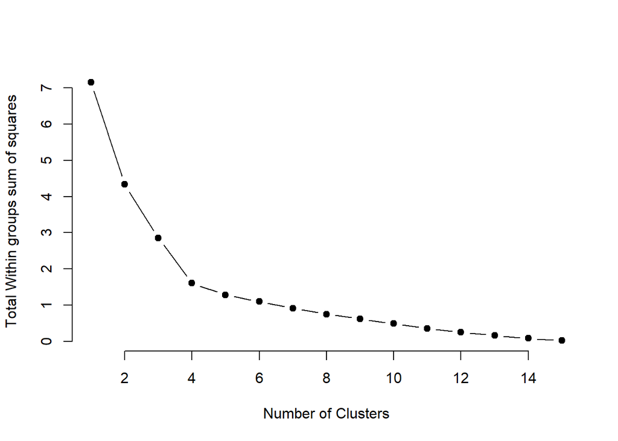

```r
# Elbow curve
# See where the curve flattens. After this point there's no more explanation of most of the variance in data.
set.seed(20)
clusterdata <- getCodes(som_model)

kmax <- 15L
wss <- sapply(1L:kmax, function(k) { kmeans(clusterdata, k, nstart = 20L)$tot.withinss })
plot(1L:kmax, wss, type = "b", pch = 19L, frame = FALSE,
     xlab = "Number of Clusters", ylab = "Total Within groups sum of squares")
```

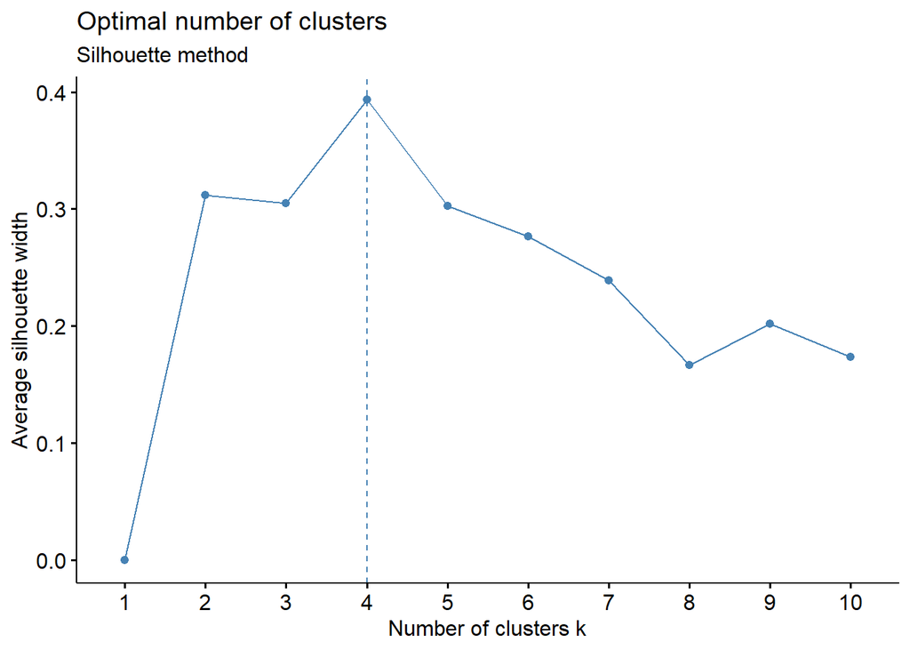

```r
# Silhouette score

require(factoextra)
fviz_nbclust(clusterdata, kmeans, method = "silhouette") +
  labs(subtitle = "Silhouette method")
```

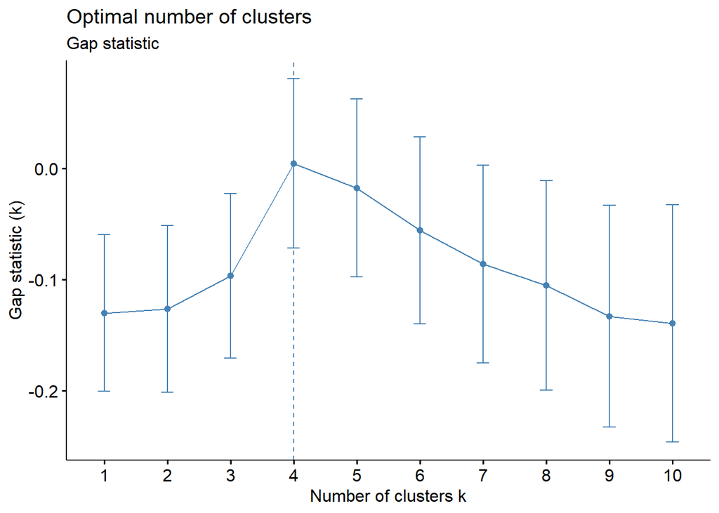

```r
# Gap statistic
# https://statweb.stanford.edu/~gwalther/gap

require(factoextra)
set.seed(123)
fviz_nbclust(clusterdata, kmeans, nstart = 25L, method = "gap_stat", nboot = 500L) +
  labs(subtitle = "Gap statistic")
```

## Cluster Visualisierung

Für die Visualisierung der Ergebnisse gibt es verschiedene Möglichkeiten. Im folgenden Werden zwei Möglichkeiten angewandt und kurz vorgestellt.

### 1. Möglichkeit: Fan-Diagramme

Darstellung der Grid-Units in ihrer hexagonale Anordnung. Es wurde je ein Diagramm für die Anzahl Cluster 1 bis 10 erstellt. Die Farbe der Grid-Units repräsentiert das Cluster zu dem diese Grid-Unit (un damit auch die ihr zugeordneten Personen) zugeordnet wurden. Die Fan-Diagramme innerhalb der Grid-Units zeigen die Ausprägungen der Merkmale (also des Codebook-Vektors). Ist ein Fan klein ist dessen Ausprägung gering. Da die Werte auf 0 bis 1 skaliert wurden ist eine hohe Ausprägung 1 und eine geringe Auspräung 0. (Die Bedeutung der Ausprägung entnehmen Sie bitte der Legende). Innerhalb eines Clusters kann so nach Überschneidungen und Merkmalskombinationen gesucht werden.

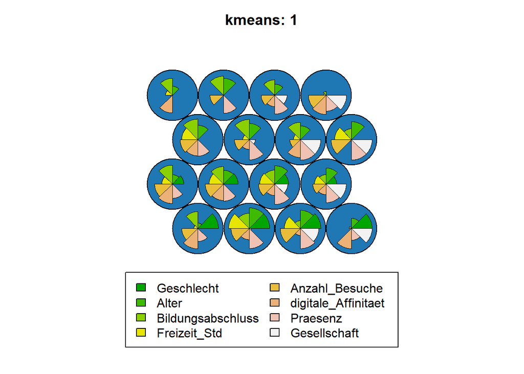

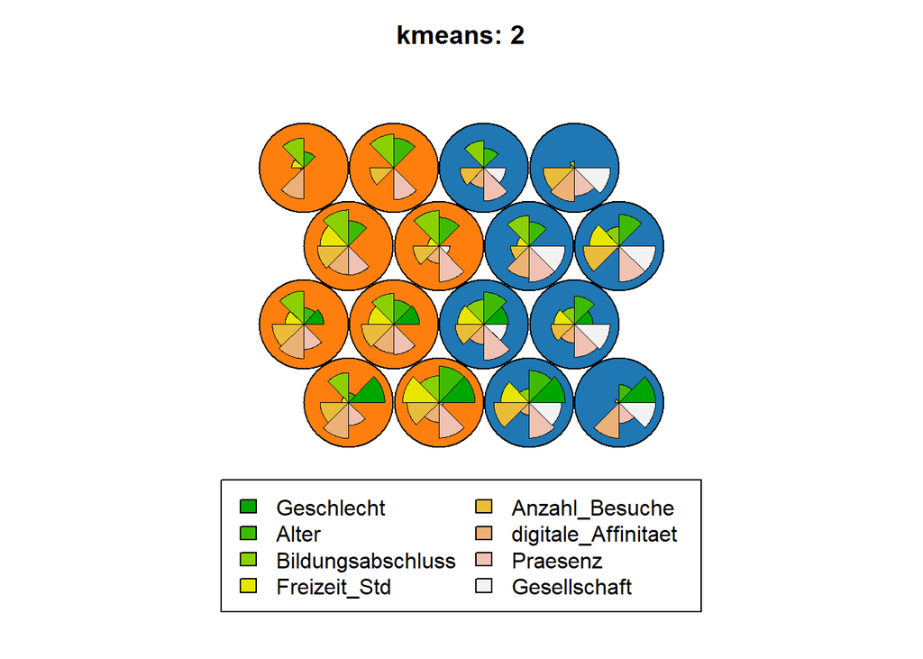

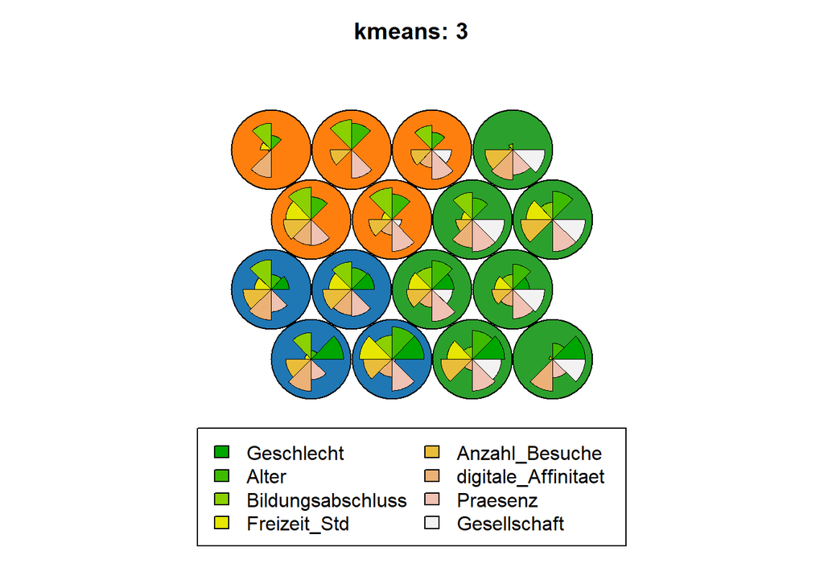

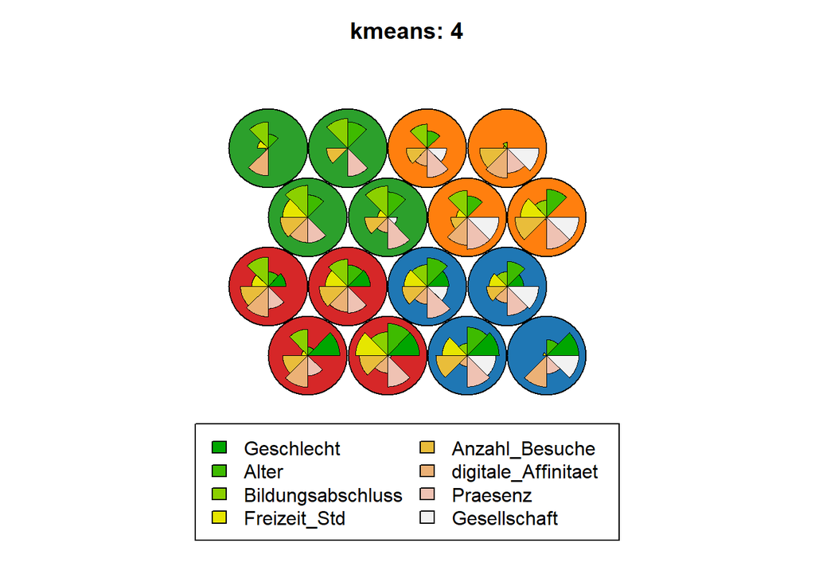

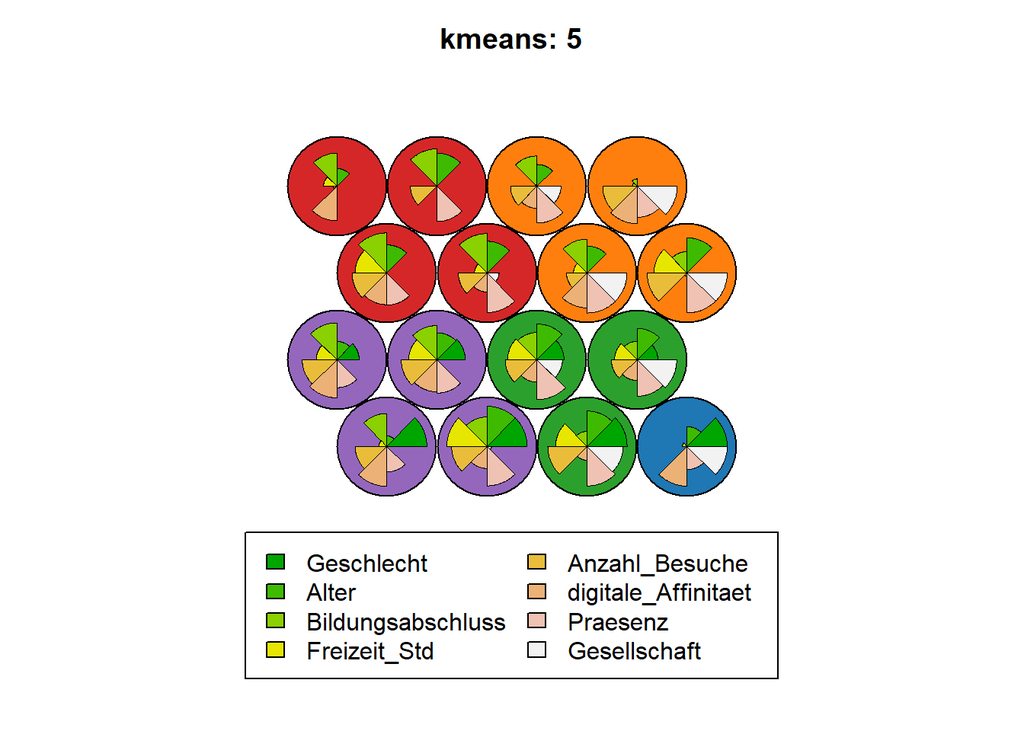

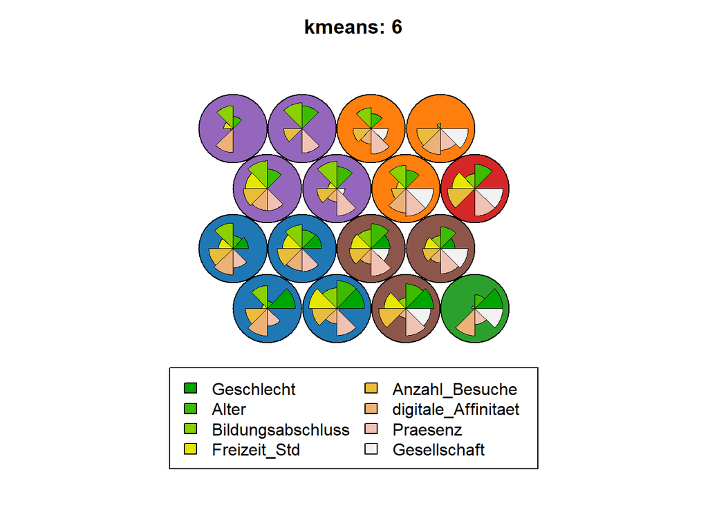

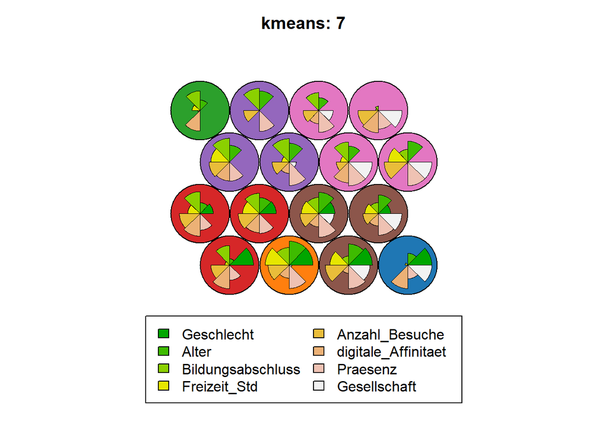

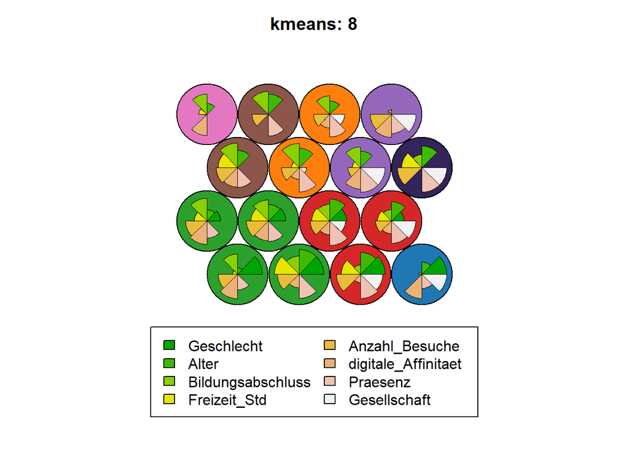

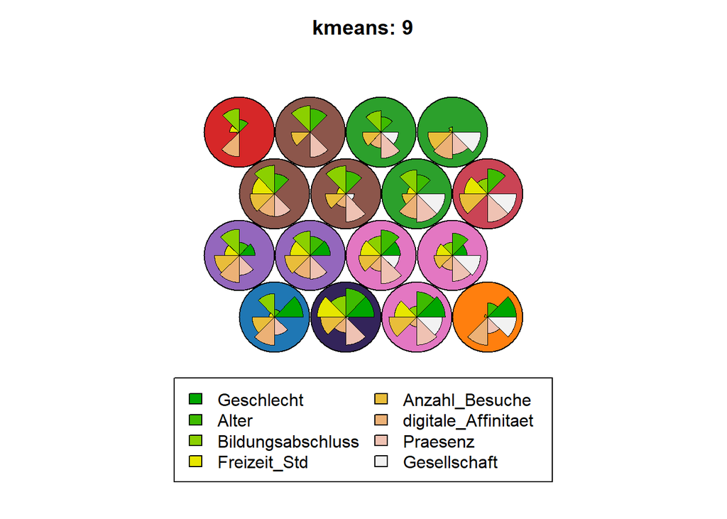

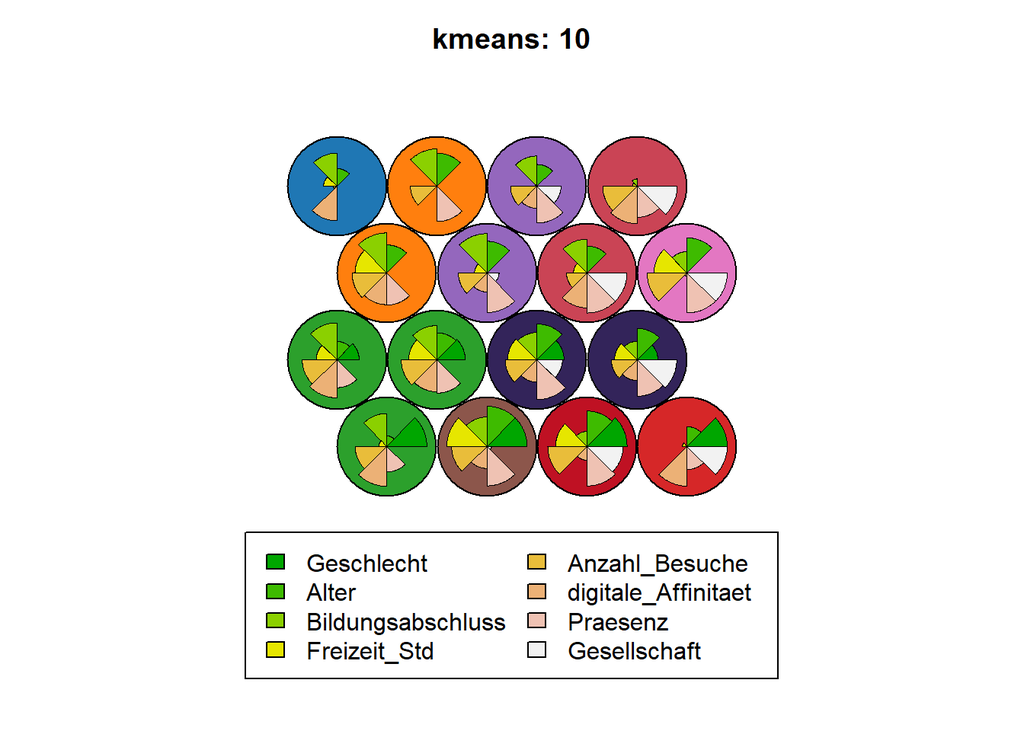

```r
# Form clusters on grid
# Try several cluster algorithms and different numbers of clusters k

max_cluster <- 10L
clusterdata <- getCodes(som_model)

# Capture outputs within a list structure
som_clusters <- list(
  model = list(),
  kmeans = list(),
  hierarchical = list()
)

for (k in seq_len(max_cluster)) {

  ## k-means clustering
  som_cluster_kmeans <- kmeans(clusterdata, centers = k, iter.max = 100L, nstart = 10)$cluster
  som_clusters$kmeans[[toString(k)]] <- som_cluster_kmeans

  ## Hierarchical clustering
  som_cluster_hierarchical <- cutree(hclust(dist(clusterdata)), k = k)
  som_clusters$hierarchical[[toString(k)]] <- som_cluster_hierarchical
}

# Plot clusters
rgb_palette <- c("#1f77b4", '#ff7f0e', '#2ca02c', '#d62728', '#9467bd', '#8c564b', '#e377c2', '#33245a', '#ca4455', '#bf1123')
plotSOM <- function(clusters, title) {
  plot(som_model, type = "codes", bgcol = rgb_palette[clusters], keepMargins = F, col = NA, main = title)
}

for (k in seq_len(max_cluster)) plotSOM(som_clusters$kmeans[[toString(k)]], paste0("kmeans: ", k))
```

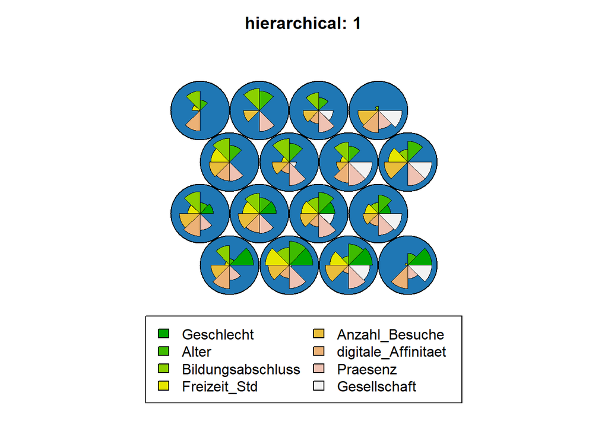

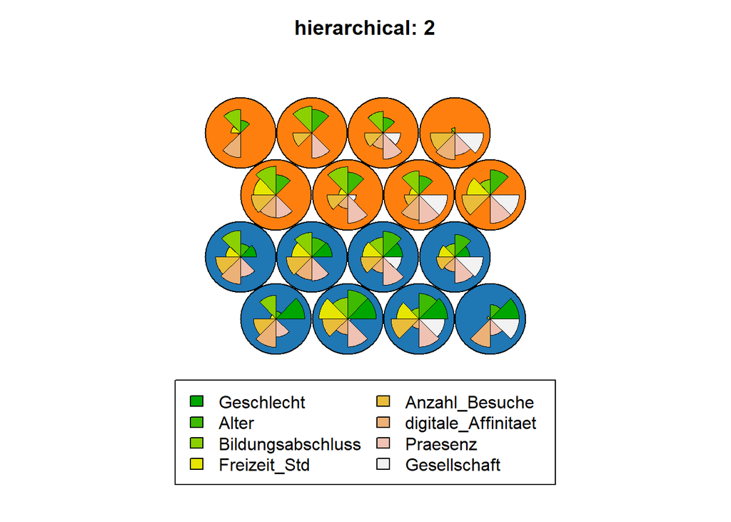

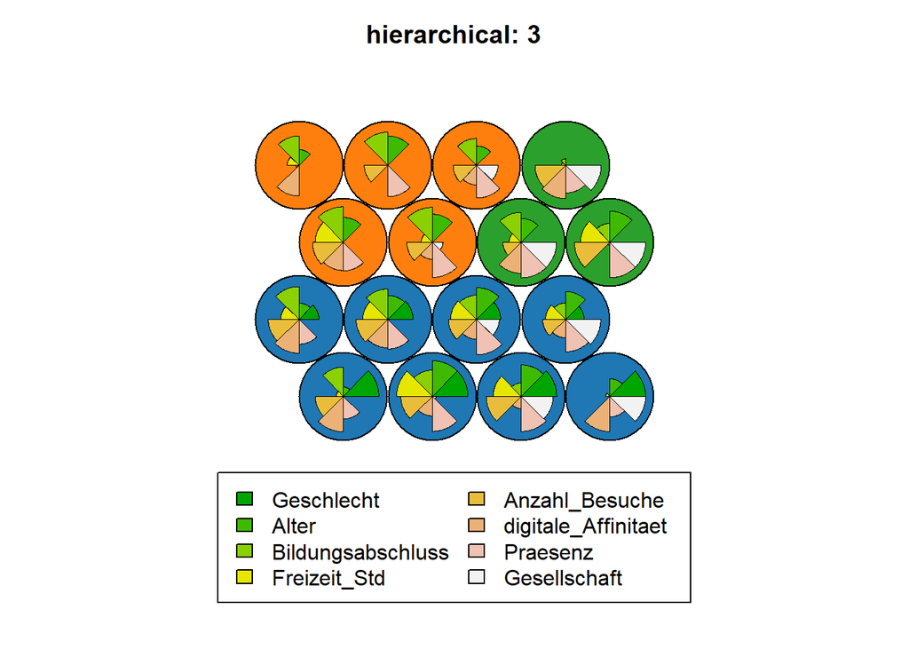

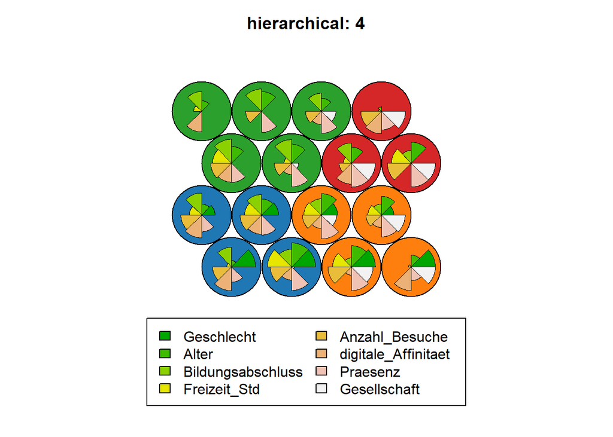

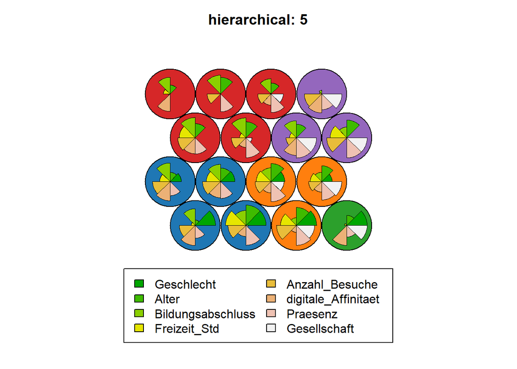

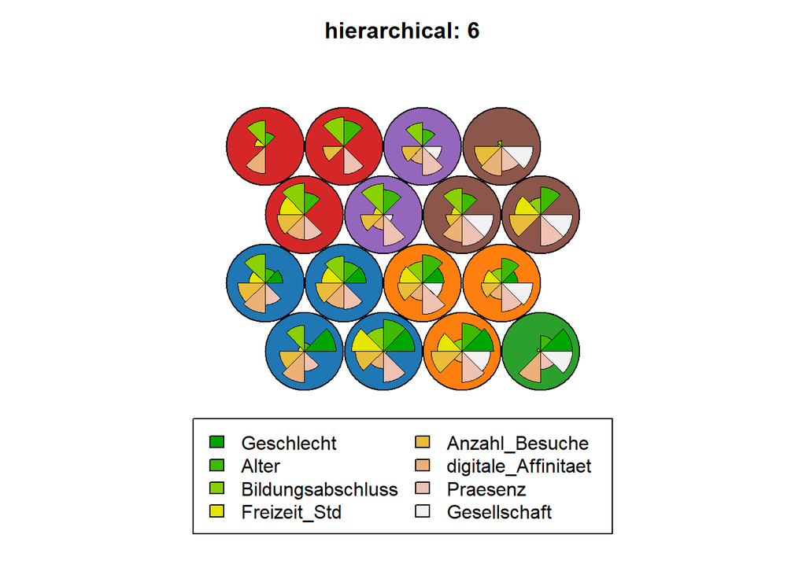

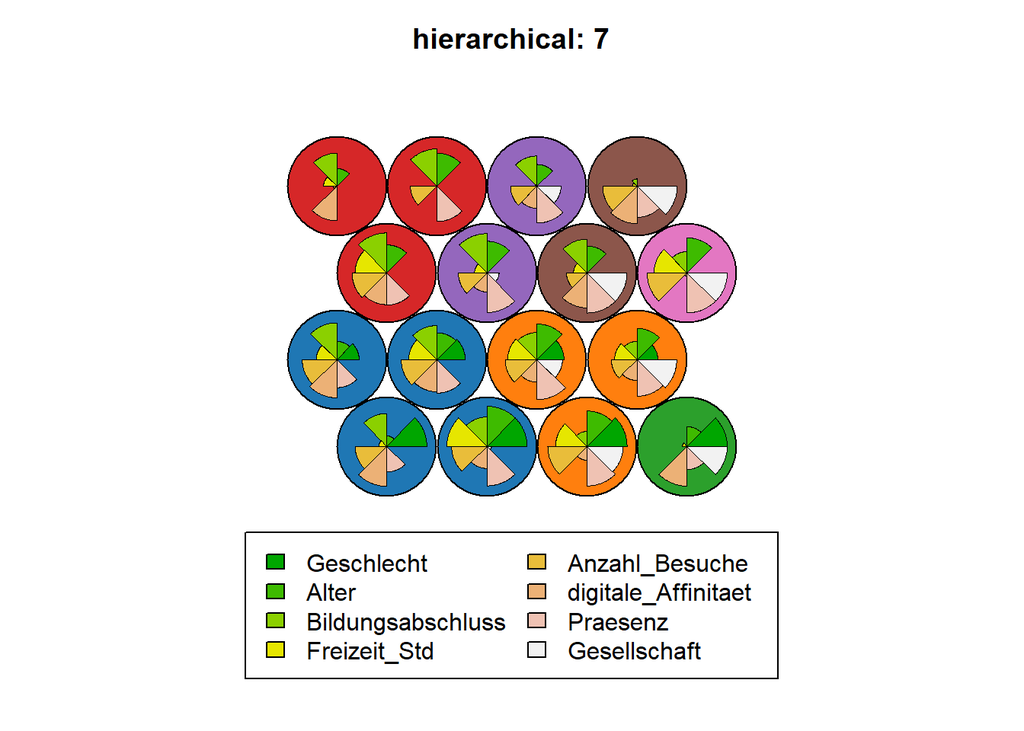

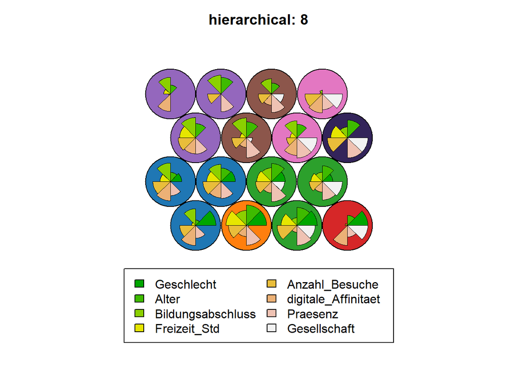

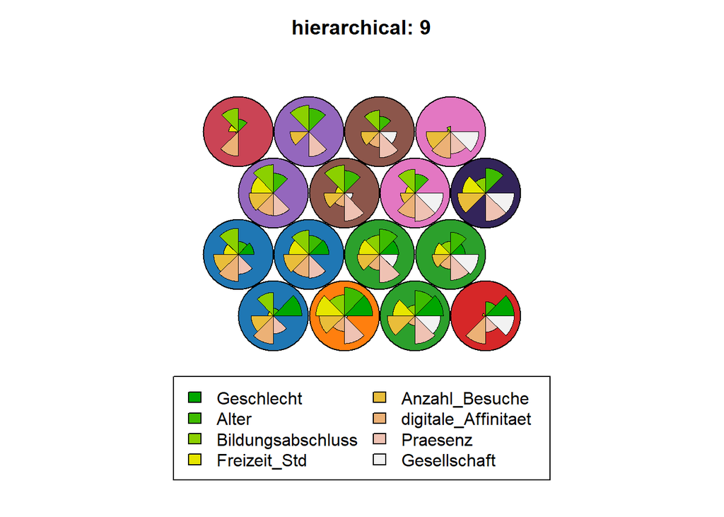

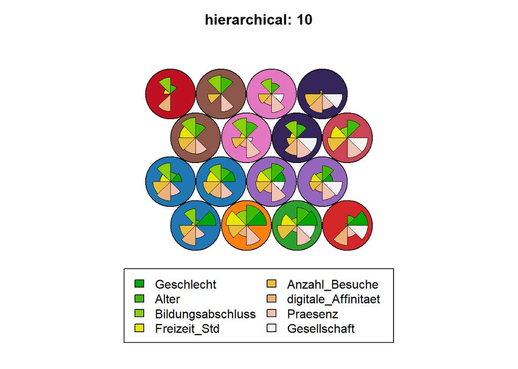

```r
for (k in seq_len(max_cluster)) plotSOM(som_clusters$hierarchical[[toString(k)]], paste0("hierarchical: ", k))
```

### 2. Möglichkeit: Balkendiagramm

Jede Grid-Unit wird durch einen Balken repräsentiert. Die Ausprägungen der Merkmale dieser Grid-Unit sind in der Länge der Balken der einzelen Merkmale zu entnehmen. Die Grid-Units können nach der Ausprägung aller Merkmale sortiert werden. Daher gibt es mehrere Balkendiagramme. So kann nach Gemeinsamkeiten und Trends zwischen den Grid-Units gesucht werden und auf diese Art und Weise einzelne Cluster ausgemacht werden.

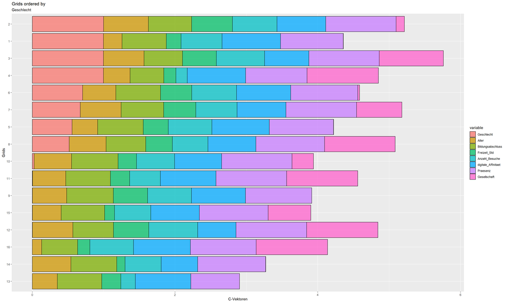

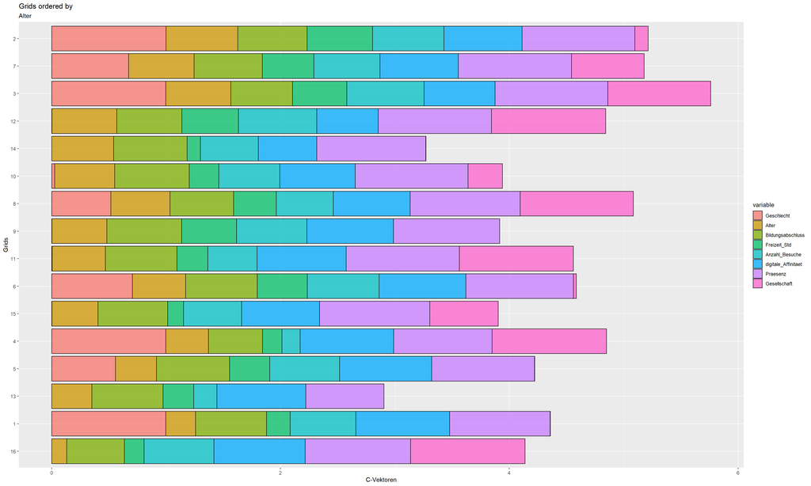

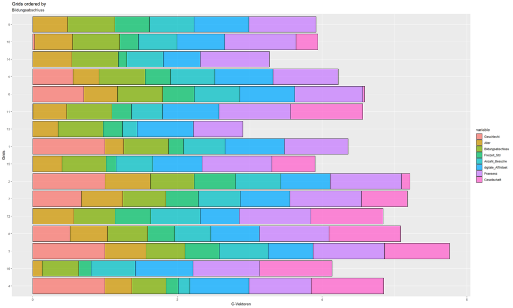

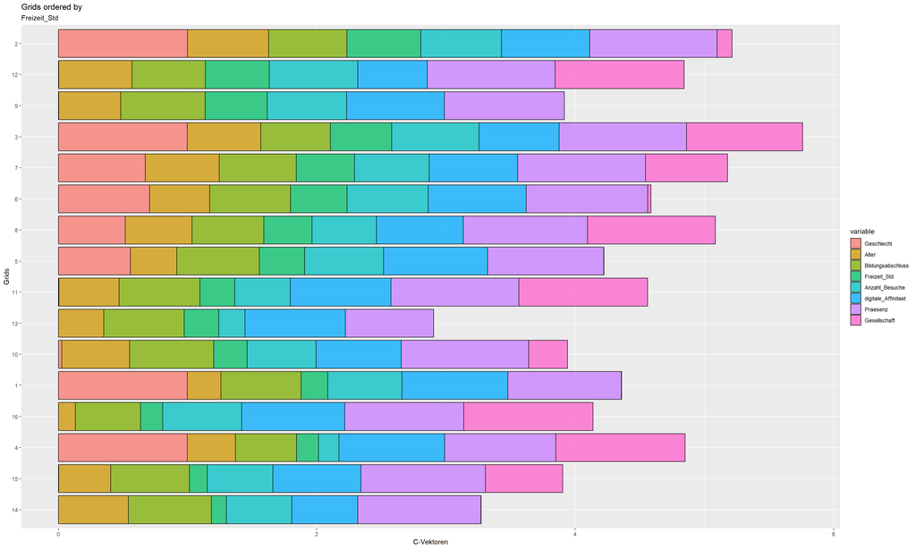

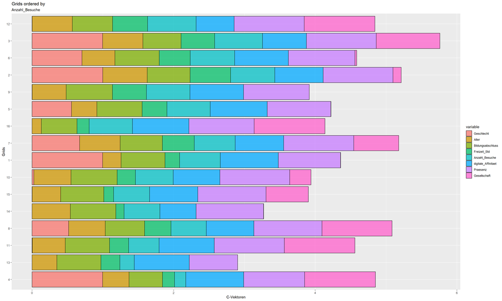

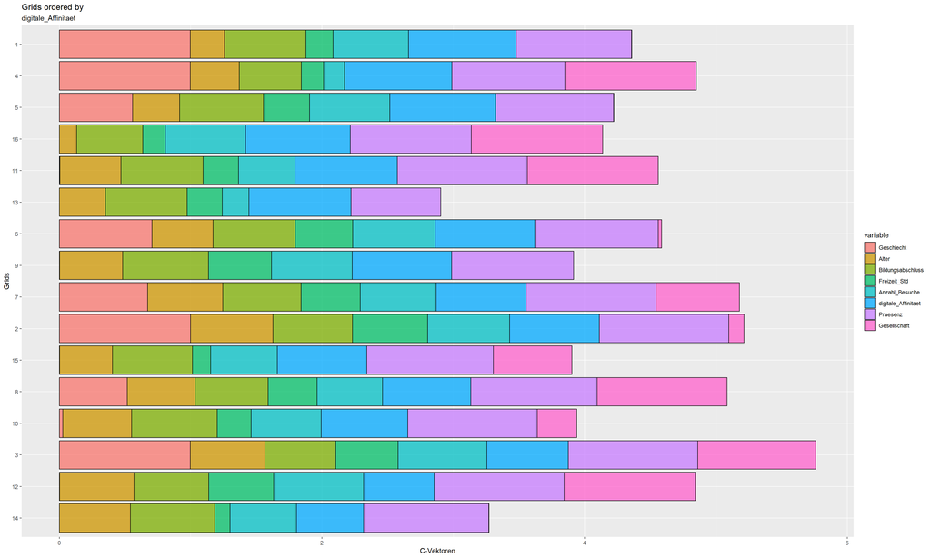

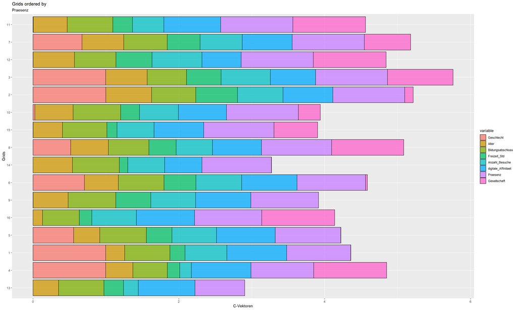

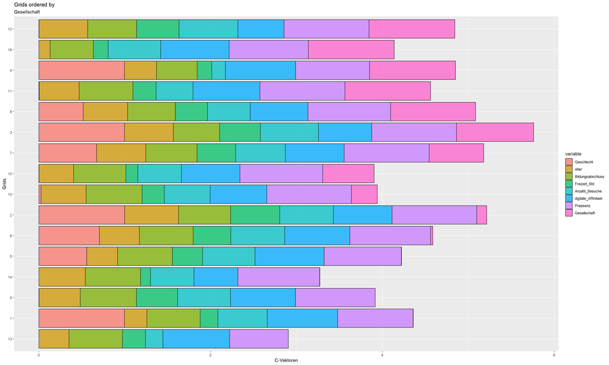

```r
codes <- getCodes(som_model)
plotdata <- data.frame(cluster = as.factor(seq_len(NROW(codes))),codes)
plotdata <- plotdata[order(plotdata$Alter),]
plotdata_long <-  melt(plotdata, id.vars = "cluster")


for(i in unique(plotdata_long$variable)){
  level_order = plotdata_long %>%
  filter(variable == i) %>%
  group_by(cluster) %>%
  summarize(val = sum(value), .groups = "drop") %>%
  arrange(val) %>%
  pull(cluster)

  plotdata_long = mutate(plotdata_long, cluster = factor(cluster, levels = level_order))

    p <- (plotdata_long %>%
    ggplot(aes(x = cluster, y = value,fill = variable,group = (cluster))) +
    geom_col(position = "stack", color = "black", alpha = .75) +
    coord_flip() +
    ggtitle("Grids ordered by",i) + xlab("Grids") + ylab("C-Vektoren"))
    print(p)}
```

### 2. Möglichkeit - Ohne leere Grits

Zur Veranschaulichung und besseren Interpretierbarkeit wurden in diesem Balkendiagramm die Grid-Units entfernt, die zu keiner Person die BMU waren.

Sollte es keine leeren Grid-Units in dem Modell geben, ist diese Visualisierung obsolet.

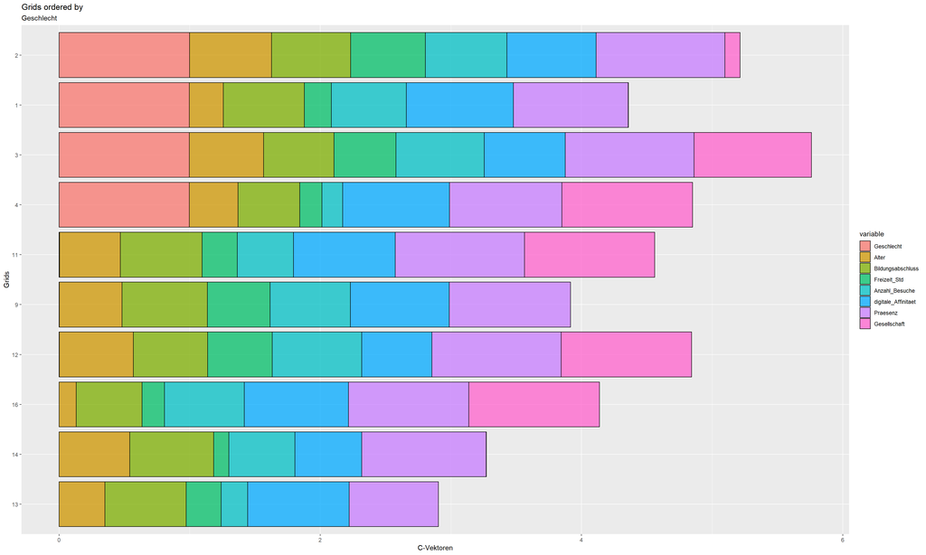

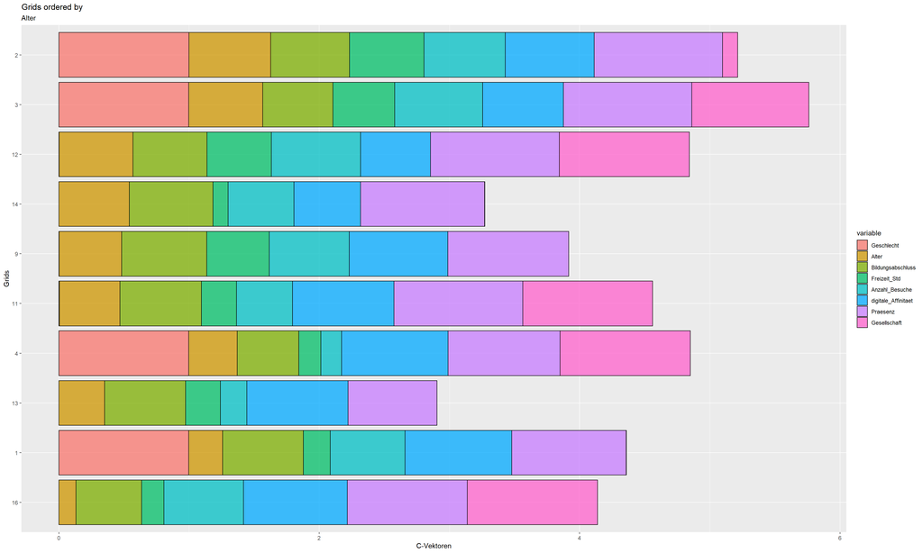

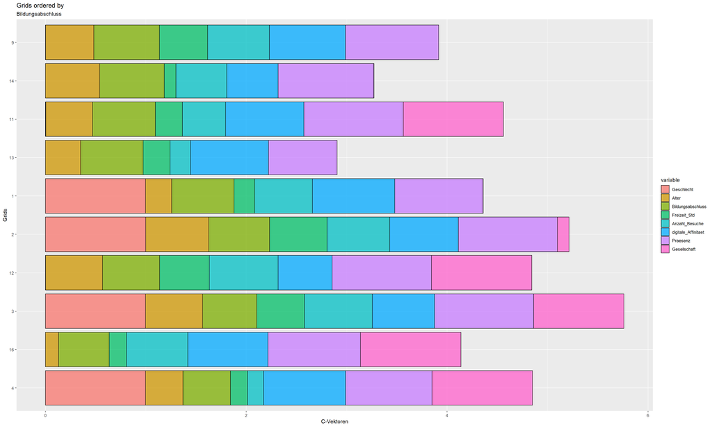

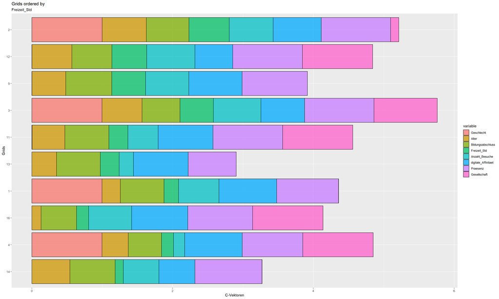

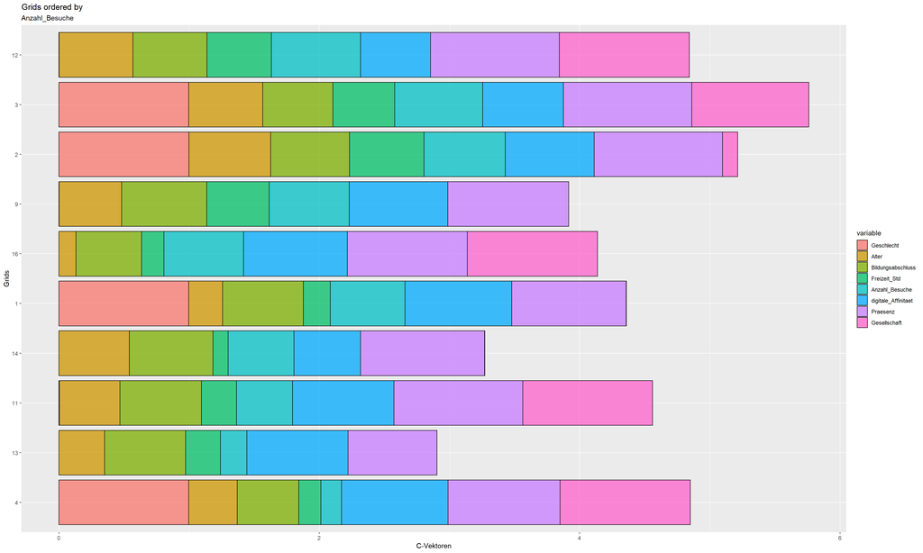

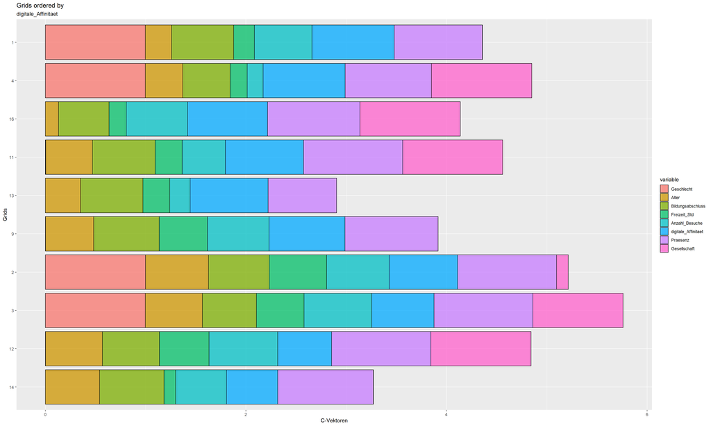

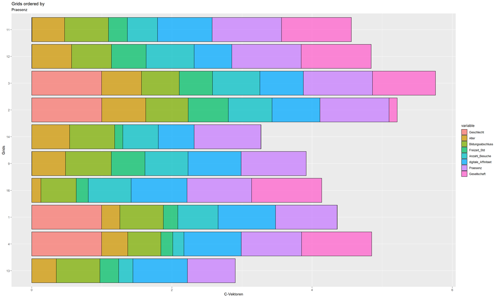

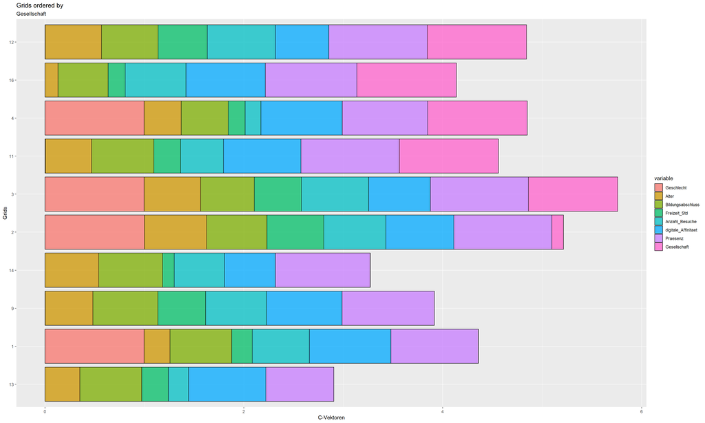

```r
codes <- getCodes(som_model)
plotdata <- data.frame(cluster = as.factor(seq_len(NROW(codes))),codes)


gritclust <-  c(1:som_numbers)
gritperson <- data.frame()
gritnumber <- data.frame(Cluster = c(1:som_numbers))

for(i in (gritclust)){
  person <- c(length(which(som_model$unit.classif == i)))
  gritperson <- rbind(gritperson, data.frame(t(person),row.names=NULL))}

gritunits <- cbind(gritnumber,gritperson)
colnames(gritunits)[2] <- "Anzahl_Personen"


Behalten <- c(1:length(plotdata$cluster))
Behalten <- Behalten[-which(gritunits$Anzahl_Personen == 0)]

plotdata <- plotdata[Behalten,]
plotdata_long <-  melt(plotdata, id.vars = "cluster")




for(i in unique(plotdata_long$variable)){
  level_order = plotdata_long %>%
  filter(variable == i) %>%
  group_by(cluster) %>%
  summarize(val = sum(value), .groups = "drop") %>%
  arrange(val) %>%
  pull(cluster)

  plotdata_long = mutate(plotdata_long, cluster = factor(cluster, levels = level_order))

    p <- (plotdata_long %>%
    ggplot(aes(x = cluster, y = value,fill = variable,group = (cluster))) +
    geom_col(position = "stack", color = "black", alpha = .75) +
    coord_flip() +
    ggtitle("Grids ordered by",i) + xlab("Grids") + ylab("C-Vektoren"))
    print(p)}
```